# Application of machine learning to microbiome data

Jakob Wirbel & Georg Zeller

12 June 2018

# Contents

**LAST UPDATED**

```
   [1] "Jun 12 2018"
```

# 1 Preparations

We first set global chunk options and load the necessary packages.

```r
library("rmarkdown")
library("BiocStyle")
library("mlr")
library("pROC")
```

```r
library("ggplot2")

set.seed(2018)
```

# 2 Introduction

This tutorial aims at illustrating how machine learning methods can be applied to associate gut microbiome composition (that is abundance profiles of various microbial species dwelling in our guts) with properties of the host. This is an area of intense research with pomising reports for many human disorders as illutrated by the figure.

[figure not shown]

In the following, we will train classifiers to recognize colorectal cancer based on the microbial composition of stool samples. For this we use data from [Zeller et al. Mol Syst Biol., 2014](http://onlinelibrary.wiley.com/doi/10.15252/msb.20145645/abstract), where the context and motivation is also explained in more detail.

There are two major reasons motivating the application of machine learning to this kind of data:

- We are able to evaluate the accuracy of the trained models and we can make predictions on future data (generated in a similar manner). This can form the basis for developing microbiome-based clinical tests (e.g. for population screening in early cancer detection prgrams). Knowing the prediction accuracy is in this context more relevant than statistical significance.
- In contrast to “black box” models, interpretable machine learning models are generally useful for biomarker discovery (and are used as such in many other life science applications, e.g. in genomics, transcriptomics, …).

# 3 Data preprocessing

This part illustrates the microbiome-specific data preprocessing pipeline and might be of interest, but it is not crucial from a machine-learning centric point of view.

In short, the microbiome abundance profiles are converted into relative abundances and then normalized to reduce heteroscedasticity.

## 3.1 Loading the data

```r
# this is data from Zeller et al., Mol. Syst. Biol. 2014
fn.feat <- 'http://www.bork.embl.de/~zeller/public_metagenomics_data/FR-CRC-N141_tax-ab-specI.tsv'
fn.metadata <- 'http://www.bork.embl.de/~zeller/public_metagenomics_data/FR-CRC-N141_metadata.tsv'

# load patient data and convert the group column into a label vector
meta <- read.table(fn.metadata, quote='', sep='\t', header=TRUE,
                   row.names=1, check.names=FALSE)

head(meta)
```

|  | Age | BMI | Gender | AJCC_stage | FOBT | Group |
| --- | --- | --- | --- | --- | --- | --- |
| CCIS27304052ST-3-0 | 52 | 20 | F | -1 | Negative | CTR |
| CCIS15794887ST-4-0 | 37 | 18 | F | -1 | Negative | CTR |
| CCIS74726977ST-3-0 | 66 | 24 | M | -1 | Negative | CTR |
| CCIS16561622ST-4-0 | 54 | 26 | M | -1 | Negative | CTR |
| CCIS79210440ST-3-0 | 65 | 30 | M | -1 | Positive | CTR |
| CCIS82507866ST-3-0 | 57 | 24 | M | -1 | Negative | CTR |

```r
# create the label
label <- as.numeric(as.factor(meta$Group))
names(label) <- rownames(meta)
label[label == 2] <- -1
label <- as.factor(label)

# read feature matrix
feat <- read.table(fn.feat, quote='', sep='\t', header=TRUE, row.names=1,
                   check.names=FALSE)
feat <- as.matrix(feat)
feat[1:5, 1:5]
```

```
                                          CCIS27304052ST-3-0 CCIS15794887ST-4-0
   UNMAPPED                                            79083              81853
   Methanoculleus marisnigri [Cluster1]                    0                  0
   Methanococcoides burtonii [Cluster10]                   0                  0
   Thermococcus kodakarensis [Cluster100]                  0                  0
   Victivallis vadensis [Cluster1000]                      0                  0
                                          CCIS74726977ST-3-0 CCIS16561622ST-4-0
   UNMAPPED                                           273668            1.2e+05
   Methanoculleus marisnigri [Cluster1]                    0            0.0e+00
   Methanococcoides burtonii [Cluster10]                   0            0.0e+00
   Thermococcus kodakarensis [Cluster100]                  0            0.0e+00
   Victivallis vadensis [Cluster1000]                      4            9.9e-01
                                          CCIS79210440ST-3-0
   UNMAPPED                                            71157
   Methanoculleus marisnigri [Cluster1]                    0
   Methanococcoides burtonii [Cluster10]                   0
   Thermococcus kodakarensis [Cluster100]                  0
   Victivallis vadensis [Cluster1000]                      0
```

```r
# assert correspondence between featrue and label data
stopifnot(all(names(label) == colnames(feat)))

cat('Loaded data: n=', ncol(feat), ' observations (samples), each with p=',
    nrow(feat), ' variables (features).\n', sep='')
```

```
   Loaded data: n=141 observations (samples), each with p=1754 variables (features).
```

## 3.2 Library size scaling

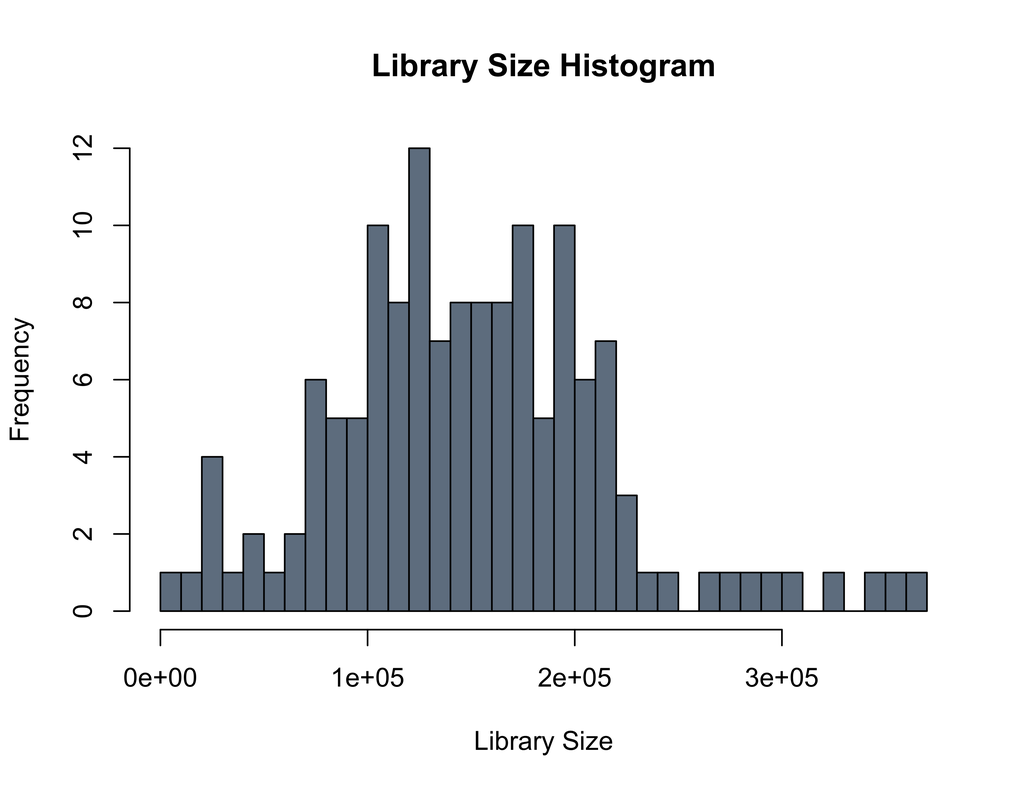

```r
# library sizes
options(repr.plot.width=5, repr.plot.height=5)
hist(colSums(feat), 30, col='slategray',
     main='Library Size Histogram', xlab='Library Size')
```

The above plots strongly suggests to correct for differences in library size (i.e. the number of sequencing reads generated for each sample). Here we use the simplest approach: conversion to relative abundances (also known as total sum scaling).

```r
# conversion to relative abundances (perhaps the library size normalization)
feat.rel <- prop.table(feat, 2)

cat('Converted read count data to relative abundances.\n')
```

```
   Converted read count data to relative abundances.
```

## 3.3 Low abundance filtering

Secondly, we discard feature with very low abundance in all samples. This is a heuristic motivated by the common believe that these are unlikely to play a major role in the gut ecosystem (they could be transient bacteria taken up with food rather than colonizers of the human gut) and their quantification has the greatest uncertainty.

```r
# unsupervised feature filtering
abundance.cutoff <- 1E-3
f.max <- apply(feat.rel, 1, max)
f.idx <- which(f.max >= abundance.cutoff)
cat('Number of features before filtering:', nrow(feat.rel), '\n')
```

```
   Number of features before filtering: 1754
```

```r
feat.filtered <- feat.rel[f.idx,]

# remove the feature that corresponds to reads
#   that could not be mapped to any species
if (rownames(feat.filtered)[1] == 'UNMAPPED' || rownames(feat.filtered)[1] == '-1') {
  feat.filtered <- feat.filtered[-1,]
}
cat('Number of features after filtering:', nrow(feat.filtered), '\n')
```

```
   Number of features after filtering: 215
```

## 3.4 Normalization

Here, we use a logarithm transformation to approximately stabilize the variance and reduce emphasis of changes in the most abundant features. There is many other alternative approaches that could make sense here but importantly we do not make use of any label information (patient status) here, and can thus apply these up front to the whole data set (and outside of the following cross validation).

```r
norm.features <- function(feat, n0=1E-6){
    # logarithmic transformation followed by standardization
    feat <- log10(feat + n0)
    m <- apply(feat, 1, mean)
    s <- apply(feat, 1, sd)
    for (r in 1:nrow(feat)) {
      feat[r,] <- (feat[r,] - m[r]) / s[r]
    }
    ret <- list(feat=feat, mean=m, sd=s, n0=n0)
    return(ret)
}

norm.par <- norm.features(feat.filtered)
feat.norm <- norm.par$feat

## change the feature names in order to comply with mlr prerequisites
rownames(feat.norm) <- make.names(rownames(feat.norm))
```

# 4 The classification problem

After these preprocessing steps, our dataset now consists of normalized gut microbiome profiles (i.e. the features) from healthy controls and from CRC patients, clinical (meta-)data for each sample, and the label (a vector containing the response variable, where +1 indicates a CRC case, and -1 a control).

Several studies have found bacteria associated with colonic cancer tissue. For example [Kostic et al.](https://europepmc.org/abstract/MED/22009990) and also [Castellarin et al.](https://europepmc.org/abstract/MED/22009989) detected higher abundance of *Fusobacterium nucleatum* in CRC patients. Let us see if we can see a similar pattern in our data (from stool samples):

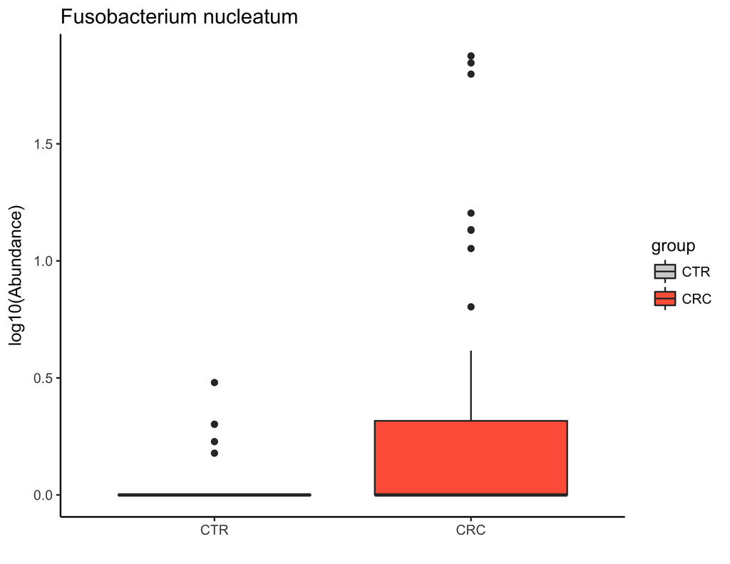

```r
df.plot <- data.frame(fuso=feat['Fusobacterium nucleatum [Cluster1479]',],
                      group=meta$Group)
# re-order
df.plot$group <- factor(df.plot$group, levels = c('CTR', 'CRC'))

ggplot(df.plot, aes(x=group, y=log10(fuso+1), fill=group)) +
  geom_boxplot() +
  theme_classic() +
  xlab('') + ylab('log10(Abundance)') +
  ggtitle('Fusobacterium nucleatum') +
  scale_fill_manual(values=c('lightgrey', 'tomato'))
```

This looks good enough to try and build a machine learning model that is able to predict the cancer status from the normalized species abundance features.

# 5 Building a LASSO classifier

## 5.1 Preparing cross validation

We will use the function below to partition data into cross validation folds.

```r
# this function returns a subset identifier for each example drawn at random
# from [1, num.folds]
# use num.folds=10 for ten-fold cross validation
partition.data <- function(label, num.folds=10) {

  fold.id <- rep(0, length(label))
  fold.id <- sample(rep(1:num.folds, length.out=length(label)))

  stopifnot(all(fold.id > 0))
  stopifnot(length(label) == length(fold.id))

  return(fold.id)
}

num.folds <- 5
fold.id <- partition.data(label, num.folds=num.folds)
cat('Prepared', num.folds, 'folds for cross validation.\n')
```

```
   Prepared 5 folds for cross validation.
```

```r
print(table(label, fold.id))
```

```
        fold.id
   label  1  2  3  4  5
      -1 23 17 15 19 14
      1   6 11 13  9 14
```

## 5.2 Creating LASSO learner

Since we want to use LASSO regression, we have to prepare the respective `mlr` learner. Here, we use the learner provided through the package `glmnet`.

The same learner can also be used for Ridge regression or Elastic Net regression, as controlled by the hyperparamter `alpha`. For LASSO regression, `alpha` has to be set to `1`.

```r
lrn.lasso <- makeLearner("classif.cvglmnet", predict.type = "prob", "alpha" = 1)
```

```r
# you could have a look at the learner and its parameters
# lrn.lasso
# lrn.lasso$par.set
```

## 5.3 Training the model

For the sake of demonstration we implement our own cross-validation scheme here, where we define a separate `mlr` training and testing task in every cross-validation fold, on which we can then train the learner created above. In the exercises below we will try and simplify this code using `mlr` cpabilities for cross validation.

```r
# prepare to save the results
# predictions
predictions <- vector(mode='numeric', length = nrow(meta))
names(predictions) <- rownames(meta)
# feature weights
feat.weights <- matrix(NA, nrow=nrow(feat.norm), ncol=num.folds,
                       dimnames = list(rownames(feat.norm),
                                       paste0('fold_', seq_len(num.folds))))

start.time <- proc.time()[1]

for (f in 1:num.folds){
  test.idx <- which(fold.id==f)
  train.idx <- setdiff(1:length(label), test.idx)

  # split the data
  train.feat <- feat.norm[,train.idx]
  train.label <- label[train.idx]
  test.feat <- feat.norm[,test.idx]
  test.label <- label[test.idx]

  # create mlr Task
  data.train <- data.frame(t(train.feat))
  data.train$label <- train.label
  data.test <- data.frame(t(test.feat))
  data.test$label <- test.label

  train.task <- makeClassifTask(data=data.train, target='label')
  test.task <- makeClassifTask(data=data.test, target='label')

  # train model
  model <- train(learner=lrn.lasso, task=train.task)

  # save feature weights
  feat.weights[,f] <- coef(model$learner.model)[-1]

  # make predictions on test set
  pred <- predict(model, test.task)
  predictions[test.idx] <- pred$data$prob.1
}

cat('Finished training models in ', proc.time()[1] - start.time, 's...', sep='')
```

```
   Finished training models in 1.8s...
```

# 6 Model evaluation and interpretation

## 6.1 Evaluation

To assess the performance of individual models, we will use Receiver Operating Characteristic curves (ROC curves). Importantly, it allows for joint visualization of the many possible trade-offs between sensitivity and specificity.

The area under the ROC curve (AUC) is a useful summary statistic for binary classifier performance with larger values indicating better performance.

In the clinical setting, the fecal occult blood test (FOBT) is often used to screen (fecal samples) for CRC. We do have the FOBT results for most of the patients in our metadata and can thus assess if our model performs better than this established clinical test for non-invasive cancer screening.

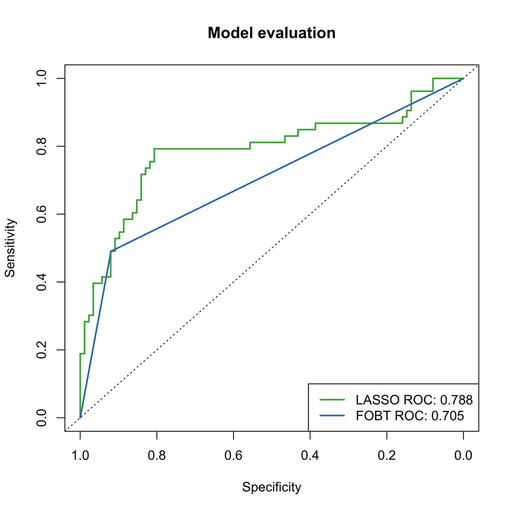

```r
# plot ROC curve
plot(NULL, type='n', xlim=c(1,0), ylim=c(0,1) ,
     xlab='Specificity', ylab='Sensitivity',
     main='Model evaluation')
abline(1,-1, lty=3)

# microbiome model AUC
auc.microbiome <- roc(predictor=predictions, response=label,
                      cases = 1, plot=TRUE, add=TRUE, col='#4daf4a')$auc


# get FOBT information into numeric form
fobt <- as.numeric(meta$FOBT)
auc.fobt <- roc(predictor=fobt, response=label,
                cases = 1, plot=TRUE, add=TRUE, col='#377eb8')$auc

# legend
legend('bottomright',
       legend=paste0(c('LASSO ROC: ', 'FOBT ROC: '),
                     formatC(c(auc.microbiome, auc.fobt), digits = 3)),
       col=c('#4daf4a', '#377eb8'), lty=1, lwd=2)
```

## 6.2 Interpretation

Below we visualize the feature weights for the LASSO model. For simplicity, we average the coefficients across cross-validation folds (but one could also use, e.g., the median and additionally visualize their variance across models).

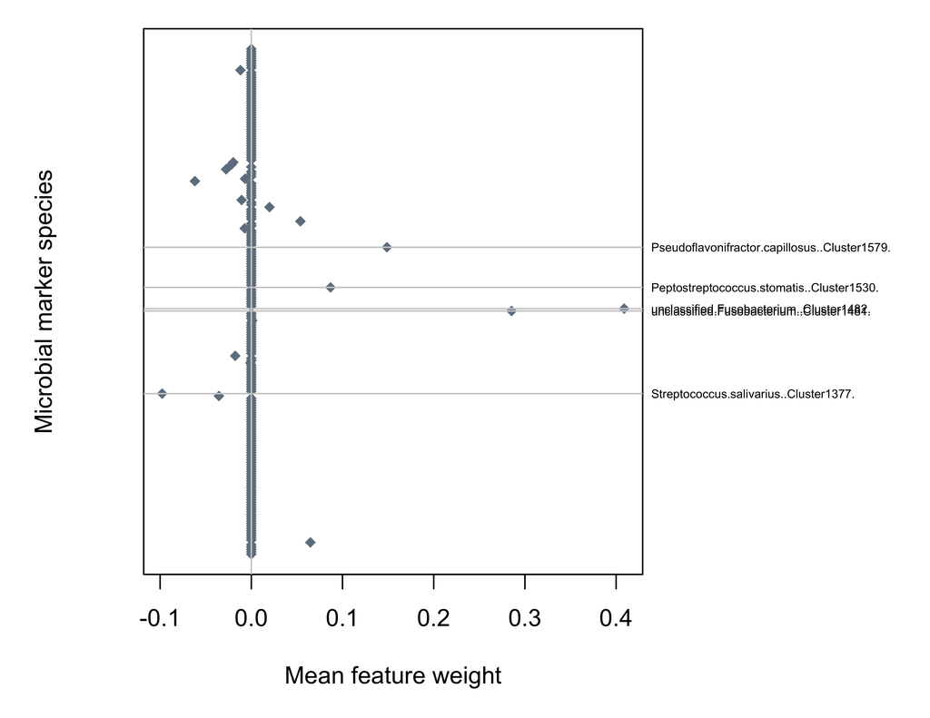

```r
# take the means of the feature weights
feat.weights.mean <- rowMeans(feat.weights)

# extract some of the top features
n.top <- 5
top.feat <- which(rank(abs(feat.weights.mean)) > nrow(feat.norm) - n.top)

# set right margin to be bigger
par(mar=c(5,5,1,10))
plot(feat.weights.mean, 1:nrow(feat.norm),
     pch=18, xlab='Mean feature weight',
     ylab='Microbial marker species',
     yaxt='n', col='slategrey')
abline(v=0, col='gray80')

# label top features
for (h in top.feat) {
  abline(h=h, col='gray80')
  mtext(rownames(feat.norm)[h], side=4,
        at=h, las=2, cex=0.5, line=0.3)
}
```

# 7 Exercises and possible extensions

1. Instead of the hand-written CV above, use mlr capabilities to achieve the same. Use stratified CV to see whether this reduces the variation seen between different folds and explore different performance measures.
2. Use another machine learning method from `mlr`, e.g. Random Forests or Ridge regression, instead of the LASSO and compare how well the different models perform.
3. The model based on microbiome data seems to perform better than the FOBT test. Have a look into `pROC`’s capabilities of plotting confidence intervals around ROC curves and statistical tests for comparing them. Is the area under ROC curve a resonably summary statistic for the FOBT performance? Check if the sensitivity of the microbiome-based model is significantly better than that of the FOBT test at the same specificity.
4. Apply the trained models to external (holdout test) data, i.e. the CN-CRC data set (see below) and evaluate the accuracy. This should be straightforward with the provided data preprocessing pipeline (Note however that ideally, the new data set should be normalized in the same way as the cross-validation data – this type of ‘frozen normalization’ requires saving and re-using the original normalization parameters).
5. [Bio] Run the above workflow on both the FR-CRC and the CN-CRC data sets and compare the top feature weights, e.g. the robustness of these as biomarkers for colorectal cancer.

A similar dataset of CRC patients and healthy controls is available here:

```r
# this is the external dataset from Feng et al., Nat. Commun. 2015
fn.feat.cn <- 'http://www.bork.embl.de/~zeller/public_metagenomics_data/CN-CRC-N128_tax-ab-specI.tsv'
fn.metadata.cn <- 'http://www.bork.embl.de/~zeller/public_metagenomics_data/CN-CRC-N128_metadata.tsv'


meta.cn <- read.table(fn.metadata.cn, quote='', sep='\t', header=TRUE,
                      row.names=1, check.names=FALSE)

head(meta.cn)
```

|  | Age | BMI | Gender | Group |
| --- | --- | --- | --- | --- |
| ERR1018240 | 59 | 26 | M | CTR |
| ERR1018195 | 65 | 21 | M | CTR |
| ERR1018209 | 62 | 21 | F | CTR |
| ERR1018239 | 64 | 26 | F | CTR |
| ERR1018238 | 55 | 26 | M | CTR |
| ERR1018237 | 69 | 25 | F | CTR |

```r
# create the label
label.cn <- as.numeric(as.factor(meta.cn$Group))
names(label.cn) <- rownames(meta.cn)
label.cn[label.cn == 2] <- -1
label.cn <- as.factor(label.cn)

# read feature matrix
feat.cn <- read.table(fn.feat.cn, quote='', sep='\t', header=TRUE,
                      row.names=1, check.names=FALSE)
feat.cn <- as.matrix(feat.cn)
feat.rel.cn <- prop.table(feat.cn, 2)
```

```
   R version 3.4.3 (2017-11-30)
   Platform: x86_64-apple-darwin15.6.0 (64-bit)
   Running under: macOS High Sierra 10.13.2

   Matrix products: default
   BLAS: /Library/Frameworks/R.framework/Versions/3.4/Resources/lib/libRblas.0.dylib
   LAPACK: /Library/Frameworks/R.framework/Versions/3.4/Resources/lib/libRlapack.dylib

   locale:
   [1] en_US.UTF-8/en_US.UTF-8/en_US.UTF-8/C/en_US.UTF-8/en_US.UTF-8

   attached base packages:
   [1] stats     graphics  grDevices utils     datasets  methods   base

   other attached packages:
   [1] ggplot2_2.2.1     pROC_1.12.1       mlr_2.12.1        ParamHelpers_1.10
   [5] rmarkdown_1.9     knitr_1.20        BiocStyle_2.6.1

   loaded via a namespace (and not attached):
    [1] Rcpp_0.12.17      magrittr_1.5      splines_3.4.3     munsell_0.4.3
    [5] lattice_0.20-35   colorspace_1.3-2  rlang_0.2.1       stringr_1.3.1
    [9] plyr_1.8.4        tools_3.4.3       parallel_3.4.3    grid_3.4.3
   [13] checkmate_1.8.5   data.table_1.11.4 gtable_0.2.0      xfun_0.1
   [17] htmltools_0.3.6   survival_2.42-3   lazyeval_0.2.1    yaml_2.1.19
   [21] rprojroot_1.3-2   digest_0.6.15     tibble_1.4.2      bookdown_0.7
   [25] Matrix_1.2-14     base64enc_0.1-3   evaluate_0.10.1   parallelMap_1.3
   [29] stringi_1.2.2     pillar_1.2.3      compiler_3.4.3    BBmisc_1.11
   [33] scales_0.5.0      backports_1.1.2
```